# IE6400 Foundations for Data Analytics Engineering

# Fall 2023

### Module 2: Exploratory Data Analysis (EDA)

Exploratory Data Analysis (EDA) is an approach to analyzing datasets to summarize their main characteristics, often with visual methods. It is a crucial step before building machine learning models, as it helps to understand the data, identify patterns, spot anomalies, test hypotheses, and check assumptions. EDA provides a better understanding of data variables and the relationships between them, and it helps in identifying which variables are important for the problem.

#### Key Components of EDA:

- Summary Statistics: Provides basic statistical details of the dataset such as mean, median, standard deviation, minimum, and maximum values.
- Data Cleaning: Identifying and handling missing values. Removing duplicates and outliers.
- Data Visualization: Using plots and graphs to visualize the data distribution, frequency, and relationships between variables. Common plots include histograms, bar charts, box plots, scatter plots, and correlation matrices.
- Correlation Analysis: Analyzing the relationship between numerical variables in the dataset. Helps in understanding how variables are connected and how they affect each other.
- Pattern Recognition: Identifying patterns and trends within the data. Helps in making informed assumptions and hypotheses.
- Feature Engineering: Creating new features or modifying existing ones to improve model performance.
- Problem Framing: Understanding the problem and determining the type of analysis or model to use.

#### Exercise 1 Load and Understand the Data

In this exercise, we will use the employee dataset.

```python
import pandas as pd

data = pd.read_csv('employee.csv')
```

```python
# Displaying using Jupyter Notebook
data
```

|  | First Name | Gender | Salary | Bonus % | Senior Management | Team |
| --- | --- | --- | --- | --- | --- | --- |
| 0 | Douglas | Male | 97308.0 | 6.945 | True | Marketing |
| 1 | Thomas | Male | 61933.0 | NaN | True | NaN |
| 2 | Jerry | Male | NaN | 9.340 | True | Finance |
| 3 | Dennis | n.a. | 115163.0 | 10.125 | False | Legal |
| 4 | NaN | Female | 0.0 | 11.598 | NaN | Finance |
| 5 | Angela | NaN | NaN | 18.523 | True | Engineering |
| 6 | Shawn | Male | 111737.0 | 6.414 | False | na |
| 7 | Rachel | Female | 142032.0 | 12.599 | False | Business Development |
| 8 | Linda | Female | 57427.0 | 9.557 | True | Client Services |
| 9 | Stephanie | Female | 36844.0 | 5.574 | True | Business Development |
| 10 | NaN | NaN | NaN | NaN | NaN | NaN |

- Import the dataset into the DataFrame.
- Examine the first few rows to get a sense of the data's structure.
- Check the data types of each column (numerical, categorical, datetime, etc.)

#### Exercise 2 Understanding the Structure of the Data

If you are working with a DataFrame and want to see the first few rows to check the data, you can use the .head() method:

```python
# Display the first few rows
print(data.head())
```

```
  First Name  Gender    Salary  Bonus % Senior Management       Team
0    Douglas    Male   97308.0    6.945              True  Marketing
1     Thomas    Male   61933.0      NaN              True        NaN
2      Jerry    Male       NaN    9.340              True    Finance
3     Dennis    n.a.  115163.0   10.125             False      Legal
4        NaN  Female       0.0   11.598               NaN    Finance
```

In the second step, to check the data types of each column in a DataFrame, you can use the .dtypes attribute in pandas. This attribute returns a Series with the data type of each column.

```python
# Check data types
print(data.dtypes)
```

```
First Name            object
Gender                object
Salary               float64
Bonus %              float64
Senior Management     object
Team                  object
dtype: object
```

For the example, this output indicates that the 'First name', 'Gender', Senior Management', and 'Team' columns are of object (string) data type, and the 'Salary' and 'Bonus %' columns are of float data type (float64).

If you want more detailed information about the DataFrame, including the data types, you can use the .info() method:

```python
# View detailed information about the DataFrame, including the data types
data.info()
```

```
<class 'pandas.core.frame.DataFrame'>
RangeIndex: 11 entries, 0 to 10
Data columns (total 6 columns):
 #   Column             Non-Null Count  Dtype
---  ------             --------------  -----
 0   First Name         9 non-null      object
 1   Gender             9 non-null      object
 2   Salary             8 non-null      float64
 3   Bonus %            9 non-null      float64
 4   Senior Management  9 non-null      object
 5   Team               9 non-null      object
dtypes: float64(2), object(4)
memory usage: 656.0+ bytes
```

This will print information including the number of non-null entries in each column, the data type of each column, and memory usage information.

In the last step, to check the summary of the descriptive statistics of the dataset, you can use the .describe() method in pandas. This method provides a summary of the central tendency, dispersion, and shape of the distribution of a dataset, excluding NaN values.

```python
# Summary statistics for numerical features
print(data.describe())
```

```
              Salary    Bonus %
count       8.000000   9.000000
mean    77805.500000  10.075000
std     46981.881216   3.942218
min         0.000000   5.574000
25%     52281.250000   6.945000
50%     79620.500000   9.557000
75%    112593.500000  11.598000
max    142032.000000  18.523000
```

By default, .describe() only analyzes numeric columns and returns the count, mean, standard deviation, minimum, 25th percentile (Q1), 50th percentile (median or Q2), 75th percentile (Q3), and maximum.

If you want to include the summary statistics for non-numeric columns as well, you can use the include='all' parameter:

```python
# View the summary statistics of all columns in the DataFrame
print(data.describe(include='all'))
```

```
       First Name  Gender         Salary    Bonus % Senior Management  \
count           9       9       8.000000   9.000000                 9
unique          9       3            NaN        NaN                 2
top         Jerry  Female            NaN        NaN              True
freq            1       4            NaN        NaN                 6
mean          NaN     NaN   77805.500000  10.075000               NaN
std           NaN     NaN   46981.881216   3.942218               NaN
min           NaN     NaN       0.000000   5.574000               NaN
25%           NaN     NaN   52281.250000   6.945000               NaN
50%           NaN     NaN   79620.500000   9.557000               NaN
75%           NaN     NaN  112593.500000  11.598000               NaN
max           NaN     NaN  142032.000000  18.523000               NaN

                        Team
count                      9
unique                     7
top     Business Development
freq                       2
mean                     NaN
std                      NaN
min                      NaN
25%                      NaN
50%                      NaN
75%                      NaN
max                      NaN
```

This will include statistics for non-numeric columns, such as count, unique, top, and freq.

#### Exercise 3 Summary Statistics for Numerical Features

Calculate basic statistics for numerical features (mean, median, standard deviation, etc.) to understand their central tendencies and variability

```python
# Summary statistics for numerical features
print(data.describe())
```

```
              Salary    Bonus %
count       8.000000   9.000000
mean    77805.500000  10.075000
std     46981.881216   3.942218
min         0.000000   5.574000
25%     52281.250000   6.945000
50%     79620.500000   9.557000
75%    112593.500000  11.598000
max    142032.000000  18.523000
```

#### Exercise 4 Checking for Missing Values

To check for missing values in a DataFrame in pandas, you can use the .isnull() method, which returns a DataFrame of the same shape as the original DataFrame. You can then use the .sum() method to count the number of missing values in each column.

```python
# Check for missing values
print(data.isnull().sum())
```

```
First Name           2
Gender               2
Salary               3
Bonus %              2
Senior Management    2
Team                 2
dtype: int64
```

```python
data
```

|  | First Name | Gender | Salary | Bonus % | Senior Management | Team |
| --- | --- | --- | --- | --- | --- | --- |
| 0 | Douglas | Male | 97308.0 | 6.945 | True | Marketing |
| 1 | Thomas | Male | 61933.0 | NaN | True | NaN |
| 2 | Jerry | Male | NaN | 9.340 | True | Finance |
| 3 | Dennis | n.a. | 115163.0 | 10.125 | False | Legal |
| 4 | NaN | Female | 0.0 | 11.598 | NaN | Finance |
| 5 | Angela | NaN | NaN | 18.523 | True | Engineering |
| 6 | Shawn | Male | 111737.0 | 6.414 | False | na |
| 7 | Rachel | Female | 142032.0 | 12.599 | False | Business Development |
| 8 | Linda | Female | 57427.0 | 9.557 | True | Client Services |
| 9 | Stephanie | Female | 36844.0 | 5.574 | True | Business Development |
| 10 | NaN | NaN | NaN | NaN | NaN | NaN |

```python
# Replace missing values for a numerical feature
data['Salary'].fillna(data['Salary'].mean(), inplace=True)
data
```

|  | First Name | Gender | Salary | Bonus % | Senior Management | Team |
| --- | --- | --- | --- | --- | --- | --- |
| 0 | Douglas | Male | 97308.0 | 6.945 | True | Marketing |
| 1 | Thomas | Male | 61933.0 | NaN | True | NaN |
| 2 | Jerry | Male | 77805.5 | 9.340 | True | Finance |
| 3 | Dennis | n.a. | 115163.0 | 10.125 | False | Legal |
| 4 | NaN | Female | 0.0 | 11.598 | NaN | Finance |
| 5 | Angela | NaN | 77805.5 | 18.523 | True | Engineering |
| 6 | Shawn | Male | 111737.0 | 6.414 | False | na |
| 7 | Rachel | Female | 142032.0 | 12.599 | False | Business Development |
| 8 | Linda | Female | 57427.0 | 9.557 | True | Client Services |
| 9 | Stephanie | Female | 36844.0 | 5.574 | True | Business Development |
| 10 | NaN | NaN | 77805.5 | NaN | NaN | NaN |

```python
# Replace missing values for a string feature
missing_values = ["n.a.", "NA", "n/a", "na", 0]
df = pd.read_csv('employee.csv', na_values = missing_values)
df
```

|  | First Name | Gender | Salary | Bonus % | Senior Management | Team |
| --- | --- | --- | --- | --- | --- | --- |
| 0 | Douglas | Male | 97308.0 | 6.945 | True | Marketing |
| 1 | Thomas | Male | 61933.0 | NaN | True | NaN |
| 2 | Jerry | Male | NaN | 9.340 | True | Finance |
| 3 | Dennis | NaN | 115163.0 | 10.125 | False | Legal |
| 4 | NaN | Female | NaN | 11.598 | NaN | Finance |
| 5 | Angela | NaN | NaN | 18.523 | True | Engineering |
| 6 | Shawn | Male | 111737.0 | 6.414 | False | NaN |
| 7 | Rachel | Female | 142032.0 | 12.599 | False | Business Development |
| 8 | Linda | Female | 57427.0 | 9.557 | True | Client Services |
| 9 | Stephanie | Female | 36844.0 | 5.574 | True | Business Development |
| 10 | NaN | NaN | NaN | NaN | NaN | NaN |

```python
# drops all rows with NaN values
df.dropna(axis = 0, inplace = True, how = 'all')
```

This would only remove the last row from the dataset since how = 'all' would only drop a row if all of the values are missing from it.

```python
df
```

|  | First Name | Gender | Salary | Bonus % | Senior Management | Team |
| --- | --- | --- | --- | --- | --- | --- |
| 0 | Douglas | Male | 97308.0 | 6.945 | True | Marketing |
| 1 | Thomas | Male | 61933.0 | NaN | True | NaN |
| 2 | Jerry | Male | NaN | 9.340 | True | Finance |
| 3 | Dennis | NaN | 115163.0 | 10.125 | False | Legal |
| 4 | NaN | Female | NaN | 11.598 | NaN | Finance |
| 5 | Angela | NaN | NaN | 18.523 | True | Engineering |
| 6 | Shawn | Male | 111737.0 | 6.414 | False | NaN |
| 7 | Rachel | Female | 142032.0 | 12.599 | False | Business Development |
| 8 | Linda | Female | 57427.0 | 9.557 | True | Client Services |
| 9 | Stephanie | Female | 36844.0 | 5.574 | True | Business Development |

#### Exercise 5 Checking for Duplicates

To check for duplicate rows in a DataFrame in pandas, you can use the .duplicated() method, which returns a Boolean Series indicating whether each row is a duplicate of a previous row in the DataFrame. Rows are considered duplicates if all columns have the same values.

```python
import pandas as pd

# Create a DataFrame with some duplicate rows
data = {
    'Name': ['John', 'Anna', 'John', 'Linda', 'Anna'],
    'Age': [28, 24, 28, 32, 24],
    'City': ['New York', 'Paris', 'New York', 'London', 'Paris']
}

df = pd.DataFrame(data)

# Show the DF
print(df)
```

```
    Name  Age      City
0   John   28  New York
1   Anna   24     Paris
2   John   28  New York
3  Linda   32    London
4   Anna   24     Paris
```

```python
# Check for duplicate rows in the DataFrame
print(df.duplicated())
```

```
0    False
1    False
2     True
3    False
4     True
dtype: bool
```

This output indicates that the third and fifth rows in the DataFrame are duplicates of previous rows.

To count the number of duplicate rows, you can use:

```python
# Count the number of duplicate rows in the DataFrame
print(df.duplicated().sum())
```

```
2
```

This will return 2, indicating that there are two duplicate rows in the DataFrame.

If you want to remove duplicate rows from the DataFrame, you can use the .drop_duplicates() method:

```python
# Remove duplicate rows from the DataFrame
df = df.drop_duplicates()
df
```

|  | Name | Age | City |
| --- | --- | --- | --- |
| 0 | John | 28 | New York |
| 1 | Anna | 24 | Paris |
| 3 | Linda | 32 | London |

After this operation, df will only contain unique rows. If you want to consider only certain columns when identifying duplicates, you can pass the subset parameter to both .duplicated() and .drop_duplicates() methods:

```python
# Check for duplicate rows based on the 'Name' and 'Age' columns
print(df.duplicated(subset=['Name', 'Age']))

# Remove duplicate rows based on the 'Name' and 'Age' columns
df = df.drop_duplicates(subset=['Name', 'Age'])
```

```
0    False
1    False
3    False
dtype: bool
```

#### Exercise 6 Explore Categorical Features

Exploring categorical features involves understanding the distribution of different categories and their relationships with other variables. Below are some techniques you can use to explore categorical features in a dataset using pandas and other visualization libraries in Python:

```python
import pandas as pd
import matplotlib.pyplot as plt
import seaborn as sns

# Sample DataFrame
data = {
    'Color': ['Red', 'Blue', 'Green', 'Red', 'Blue', 'Green', 'Red'],
    'Price': [23, 45, 12, 67, 34, 89, 56]
}
df = pd.DataFrame(data)
df
```

|  | Color | Price |
| --- | --- | --- |
| 0 | Red | 23 |
| 1 | Blue | 45 |
| 2 | Green | 12 |
| 3 | Red | 67 |
| 4 | Blue | 34 |
| 5 | Green | 89 |
| 6 | Red | 56 |

#### 1. Count of Unique Values:

```python
print(df['Color'].value_counts())
```

```
Red      3
Blue     2
Green    2
Name: Color, dtype: int64
```

#### 2. Bar Plot of Categories:

Use a bar plot to visualize the distribution of categories.

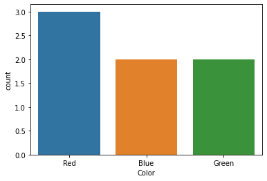

```python
import matplotlib.pyplot as plt
import seaborn as sns

sns.countplot(data=df, x='Color')
plt.show()
```

#### 3. Pie Chart:

Use a pie chart to visualize the proportion of each category.

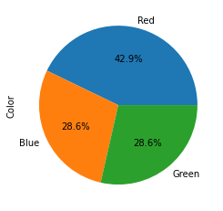

```python
df['Color'].value_counts().plot(kind='pie', autopct='%1.1f%%')
plt.show()
```

#### 4. Cross Tabulation:

Use the pd.crosstab() function to compute a cross-tabulation of two (or more) factors.

```python
print(pd.crosstab(df['Color'], df['Price']))
```

```
Price  12  23  34  45  56  67  89
Color
Blue    0   0   1   1   0   0   0
Green   1   0   0   0   0   0   1
Red     0   1   0   0   1   1   0
```

This table shows the frequency of each combination of 'Color' and 'Price'. For example, the price 23 appears 1 time with the color Red, and the price 89 appears 1 time with the color Green. All other combinations of 'Color' and 'Price' do not appear in the DataFrame, so their counts are 0.

#### 5. Box Plot:

Use a box plot to understand the distribution of a numerical variable across different categories.

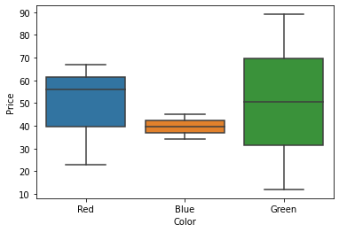

```python
sns.boxplot(data=df, x='Color', y='Price')
plt.show()
```

#### 6. Grouped Bar Plot:

Use a grouped bar plot to compare the distribution of categories in different groups.

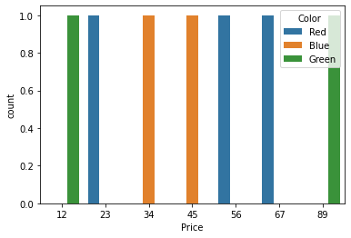

```python
sns.countplot(data=df, x='Price', hue='Color')
plt.show()
```

#### Exercise 7 Performing EDA for Google Playstore Dataset

Performing Exploratory Data Analysis (EDA) involves understanding the dataset by summarizing its main characteristics, often visually. Below are the steps to perform EDA on the googleplaystore.csv dataset, which contains information about different applications on the Google Play Store.

#### Step 1: Load the Dataset

```python
import pandas as pd

# Load the dataset
df = pd.read_csv('googleplaystore.csv')
df
```

|  | App | Category | Rating | Reviews | Size | Installs | Type | Price | Content Rating | Genres | Last Updated | Current Ver | Android Ver |
| --- | --- | --- | --- | --- | --- | --- | --- | --- | --- | --- | --- | --- | --- |
| 0 | Photo Editor & Candy Camera & Grid & ScrapBook | ART_AND_DESIGN | 4.1 | 159 | 19M | 10,000+ | Free | 0 | Everyone | Art & Design | January 7, 2018 | 1.0.0 | 4.0.3 and up |
| 1 | Coloring book moana | ART_AND_DESIGN | 3.9 | 967 | 14M | 500,000+ | Free | 0 | Everyone | Art & Design;Pretend Play | January 15, 2018 | 2.0.0 | 4.0.3 and up |
| 2 | U Launcher Lite – FREE Live Cool Themes, Hide ... | ART_AND_DESIGN | 4.7 | 87510 | 8.7M | 5,000,000+ | Free | 0 | Everyone | Art & Design | August 1, 2018 | 1.2.4 | 4.0.3 and up |
| 3 | Sketch - Draw & Paint | ART_AND_DESIGN | 4.5 | 215644 | 25M | 50,000,000+ | Free | 0 | Teen | Art & Design | June 8, 2018 | Varies with device | 4.2 and up |
| 4 | Pixel Draw - Number Art Coloring Book | ART_AND_DESIGN | 4.3 | 967 | 2.8M | 100,000+ | Free | 0 | Everyone | Art & Design;Creativity | June 20, 2018 | 1.1 | 4.4 and up |
| ... | ... | ... | ... | ... | ... | ... | ... | ... | ... | ... | ... | ... | ... |
| 10835 | Sya9a Maroc - FR | FAMILY | 4.5 | 38 | 53M | 5,000+ | Free | 0 | Everyone | Education | July 25, 2017 | 1.48 | 4.1 and up |
| 10836 | Fr. Mike Schmitz Audio Teachings | FAMILY | 5.0 | 4 | 3.6M | 100+ | Free | 0 | Everyone | Education | July 6, 2018 | 1 | 4.1 and up |
| 10837 | Parkinson Exercices FR | MEDICAL | NaN | 3 | 9.5M | 1,000+ | Free | 0 | Everyone | Medical | January 20, 2017 | 1 | 2.2 and up |
| 10838 | The SCP Foundation DB fr nn5n | BOOKS_AND_REFERENCE | 4.5 | 114 | Varies with device | 1,000+ | Free | 0 | Mature 17+ | Books & Reference | January 19, 2015 | Varies with device | Varies with device |
| 10839 | iHoroscope - 2018 Daily Horoscope & Astrology | LIFESTYLE | 4.5 | 398307 | 19M | 10,000,000+ | Free | 0 | Everyone | Lifestyle | July 25, 2018 | Varies with device | Varies with device |

10840 rows × 13 columns

#### Step 2: Understand the Dataset

```python
# Display the first few rows of the DataFrame
print(df.head())

# Information about DataFrame including the data types
print(df.info())

# Summary statistics of the DataFrame
print(df.describe(include='all'))
```

```
                                                 App        Category  Rating  \
0     Photo Editor & Candy Camera & Grid & ScrapBook  ART_AND_DESIGN     4.1
1                                Coloring book moana  ART_AND_DESIGN     3.9
2  U Launcher Lite – FREE Live Cool Themes, Hide ...  ART_AND_DESIGN     4.7
3                              Sketch - Draw & Paint  ART_AND_DESIGN     4.5
4              Pixel Draw - Number Art Coloring Book  ART_AND_DESIGN     4.3

   Reviews  Size     Installs  Type Price Content Rating  \
0      159   19M      10,000+  Free     0       Everyone
1      967   14M     500,000+  Free     0       Everyone
2    87510  8.7M   5,000,000+  Free     0       Everyone
3   215644   25M  50,000,000+  Free     0           Teen
4      967  2.8M     100,000+  Free     0       Everyone

                      Genres      Last Updated         Current Ver  \
0               Art & Design   January 7, 2018               1.0.0
1  Art & Design;Pretend Play  January 15, 2018               2.0.0
2               Art & Design    August 1, 2018               1.2.4
3               Art & Design      June 8, 2018  Varies with device
4    Art & Design;Creativity     June 20, 2018                 1.1

    Android Ver
0  4.0.3 and up
1  4.0.3 and up
2  4.0.3 and up
3    4.2 and up
4    4.4 and up
<class 'pandas.core.frame.DataFrame'>
RangeIndex: 10840 entries, 0 to 10839
Data columns (total 13 columns):
 #   Column          Non-Null Count  Dtype
---  ------          --------------  -----
 0   App             10840 non-null  object
 1   Category        10840 non-null  object
 2   Rating          9366 non-null   float64
 3   Reviews         10840 non-null  int64
 4   Size            10840 non-null  object
 5   Installs        10840 non-null  object
 6   Type            10839 non-null  object
 7   Price           10840 non-null  object
```

[output cut: 31 more lines]

```
75%            NaN    NaN    NaN            NaN    NaN             NaN
max            NaN    NaN    NaN            NaN    NaN             NaN

               Current Ver Android Ver
count                10832       10838
unique                2783          33
top     Varies with device  4.1 and up
freq                  1459        2451
mean                   NaN         NaN
std                    NaN         NaN
min                    NaN         NaN
25%                    NaN         NaN
50%                    NaN         NaN
75%                    NaN         NaN
max                    NaN         NaN
```

#### Step 3: Handle Missing Values

```python
# Count the number of missing values in each column
print(df.isna().sum())
```

```
App                  0
Category             0
Rating            1474
Reviews              0
Size                 0
Installs             0
Type                 1
Price                0
Content Rating       0
Genres               0
Last Updated         0
Current Ver          8
Android Ver          2
dtype: int64
```

```python
# Handle missing values (you can fill or drop based on the requirement)
df = df.dropna()
print(df.isna().sum())
```

```
App               0
Category          0
Rating            0
Reviews           0
Size              0
Installs          0
Type              0
Price             0
Content Rating    0
Genres            0
Last Updated      0
Current Ver       0
Android Ver       0
dtype: int64
```

#### Step 4: Handle Duplicates

```python
# Remove duplicate rows
df = df.drop_duplicates()
```

#### Step 5: Explore Categorical Features

```python
# Count of unique values for each categorical feature
print(df['Category'].value_counts())
print(df['Content Rating'].value_counts())
```

```
FAMILY                 1717
GAME                   1074
TOOLS                   733
PRODUCTIVITY            334
FINANCE                 317
PERSONALIZATION         308
COMMUNICATION           307
LIFESTYLE               305
PHOTOGRAPHY             304
MEDICAL                 302
SPORTS                  286
BUSINESS                270
HEALTH_AND_FITNESS      262
SOCIAL                  244
NEWS_AND_MAGAZINES      214
TRAVEL_AND_LOCAL        205
SHOPPING                202
BOOKS_AND_REFERENCE     177
VIDEO_PLAYERS           160
DATING                  159
EDUCATION               129
MAPS_AND_NAVIGATION     124
ENTERTAINMENT           111
FOOD_AND_DRINK          106
WEATHER                  75
AUTO_AND_VEHICLES        73
HOUSE_AND_HOME           68
LIBRARIES_AND_DEMO       64
ART_AND_DESIGN           61
COMICS                   58
PARENTING                50
EVENTS                   45
BEAUTY                   42
Name: Category, dtype: int64
Everyone           7089
Teen               1022
Mature 17+          411
Everyone 10+        360
Adults only 18+       3
Unrated               1
Name: Content Rating, dtype: int64
```

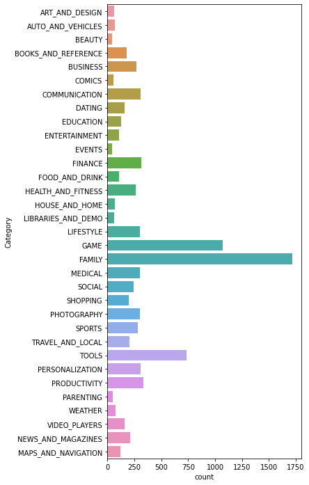

```python
# Bar Plot for Category
import seaborn as sns
import matplotlib.pyplot as plt

fig, ax = plt.subplots(figsize=(5, 12))
sns.countplot(data=df, y='Category')
plt.show()
```

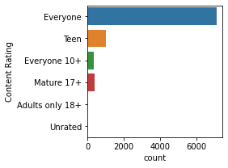

```python
# Bar Plot for Content Rating
import seaborn as sns
import matplotlib.pyplot as plt

fig, ax = plt.subplots(figsize=(3, 3))
sns.countplot(data=df, y='Content Rating')
plt.show()
```

#### Step 6: Explore Numerical Features

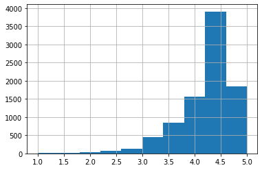

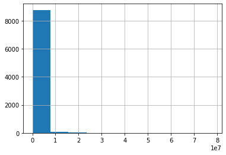

```python
# Histogram for numerical features like Rating, Reviews, and Price
df['Rating'].hist()
plt.show()

df['Reviews'].astype(int).hist()
plt.show()
```

#### Step 7: Relationship between Features

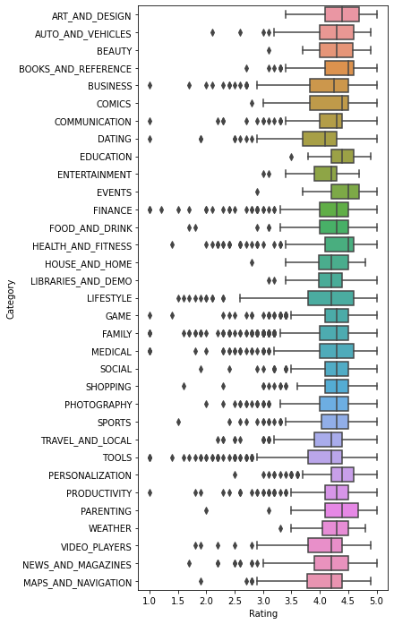

```python
# Boxplot to understand the relationship between Category and Rating
fig, ax = plt.subplots(figsize=(5, 12))
sns.boxplot(data=df, x='Rating', y='Category')
plt.show()
```

#### Step 8: Correlation Matrix

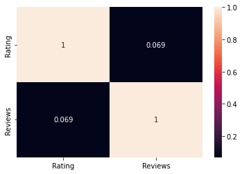

```python
# Correlation matrix to understand the relationship between numerical variables
corr_matrix = df[['Rating', 'Reviews']].astype(float).corr()
sns.heatmap(corr_matrix, annot=True)
plt.show()
```

#### Note:

- For the 'Reviews' and 'Price' columns, you may need to convert them to numerical types for numerical analysis.
- Handle the 'Installs' and 'Size' columns appropriately as they may contain special characters.
- You can perform further analysis based on the insights you want to extract from the dataset.

#### Exercise 8 Analyzing through Visualizations in Athlete Events Dataset

Analyzing the athlete_events.csv dataset through visualizations involves creating various plots to uncover patterns, relationships, and insights in the data. Below are the steps and types of visualizations you can use to analyze the Athlete Events Dataset.

#### Step 1: Load the Dataset

```python
import pandas as pd

# Load the dataset
df = pd.read_csv('athlete_events.csv')
df
```

|  | ID | Name | Sex | Age | Height | Weight | Team | NOC | Games | Year | Season | City | Sport | Event | Medal |
| --- | --- | --- | --- | --- | --- | --- | --- | --- | --- | --- | --- | --- | --- | --- | --- |
| 0 | 1 | A Dijiang | M | 24.0 | 180.0 | 80.0 | China | CHN | 1992 Summer | 1992 | Summer | Barcelona | Basketball | Basketball Men's Basketball | NaN |
| 1 | 2 | A Lamusi | M | 23.0 | 170.0 | 60.0 | China | CHN | 2012 Summer | 2012 | Summer | London | Judo | Judo Men's Extra-Lightweight | NaN |
| 2 | 3 | Gunnar Nielsen Aaby | M | 24.0 | NaN | NaN | Denmark | DEN | 1920 Summer | 1920 | Summer | Antwerpen | Football | Football Men's Football | NaN |
| 3 | 4 | Edgar Lindenau Aabye | M | 34.0 | NaN | NaN | Denmark/Sweden | DEN | 1900 Summer | 1900 | Summer | Paris | Tug-Of-War | Tug-Of-War Men's Tug-Of-War | Gold |
| 4 | 5 | Christine Jacoba Aaftink | F | 21.0 | 185.0 | 82.0 | Netherlands | NED | 1988 Winter | 1988 | Winter | Calgary | Speed Skating | Speed Skating Women's 500 metres | NaN |
| ... | ... | ... | ... | ... | ... | ... | ... | ... | ... | ... | ... | ... | ... | ... | ... |
| 271111 | 135569 | Andrzej ya | M | 29.0 | 179.0 | 89.0 | Poland-1 | POL | 1976 Winter | 1976 | Winter | Innsbruck | Luge | Luge Mixed (Men)'s Doubles | NaN |
| 271112 | 135570 | Piotr ya | M | 27.0 | 176.0 | 59.0 | Poland | POL | 2014 Winter | 2014 | Winter | Sochi | Ski Jumping | Ski Jumping Men's Large Hill, Individual | NaN |
| 271113 | 135570 | Piotr ya | M | 27.0 | 176.0 | 59.0 | Poland | POL | 2014 Winter | 2014 | Winter | Sochi | Ski Jumping | Ski Jumping Men's Large Hill, Team | NaN |
| 271114 | 135571 | Tomasz Ireneusz ya | M | 30.0 | 185.0 | 96.0 | Poland | POL | 1998 Winter | 1998 | Winter | Nagano | Bobsleigh | Bobsleigh Men's Four | NaN |
| 271115 | 135571 | Tomasz Ireneusz ya | M | 34.0 | 185.0 | 96.0 | Poland | POL | 2002 Winter | 2002 | Winter | Salt Lake City | Bobsleigh | Bobsleigh Men's Four | NaN |

271116 rows × 15 columns

#### Step 2: Basic Information and Summary Statistics

```python
# Display the first few rows of the DataFrame
print(df.head())

# Information about DataFrame including the data types
print(df.info())

# Summary statistics of the DataFrame
print(df.describe(include='all'))
```

```
   ID                      Name Sex   Age  Height  Weight            Team  \
0   1                 A Dijiang   M  24.0   180.0    80.0           China
1   2                  A Lamusi   M  23.0   170.0    60.0           China
2   3       Gunnar Nielsen Aaby   M  24.0     NaN     NaN         Denmark
3   4      Edgar Lindenau Aabye   M  34.0     NaN     NaN  Denmark/Sweden
4   5  Christine Jacoba Aaftink   F  21.0   185.0    82.0     Netherlands

   NOC        Games  Year  Season       City          Sport  \
0  CHN  1992 Summer  1992  Summer  Barcelona     Basketball
1  CHN  2012 Summer  2012  Summer     London           Judo
2  DEN  1920 Summer  1920  Summer  Antwerpen       Football
3  DEN  1900 Summer  1900  Summer      Paris     Tug-Of-War
4  NED  1988 Winter  1988  Winter    Calgary  Speed Skating

                              Event Medal
0       Basketball Men's Basketball   NaN
1      Judo Men's Extra-Lightweight   NaN
2           Football Men's Football   NaN
3       Tug-Of-War Men's Tug-Of-War  Gold
4  Speed Skating Women's 500 metres   NaN
<class 'pandas.core.frame.DataFrame'>
RangeIndex: 271116 entries, 0 to 271115
Data columns (total 15 columns):
 #   Column  Non-Null Count   Dtype
---  ------  --------------   -----
 0   ID      271116 non-null  int64
 1   Name    271116 non-null  object
 2   Sex     271116 non-null  object
 3   Age     261642 non-null  float64
 4   Height  210945 non-null  float64
 5   Weight  208241 non-null  float64
 6   Team    271116 non-null  object
 7   NOC     271116 non-null  object
 8   Games   271116 non-null  object
 9   Year    271116 non-null  int64
 10  Season  271116 non-null  object
 11  City    271116 non-null  object
 12  Sport   271116 non-null  object
 13  Event   271116 non-null  object
 14  Medal   39783 non-null   object
```

[output cut: 39 more lines]

```
75%       2002.000000     NaN     NaN        NaN                      NaN
max       2016.000000     NaN     NaN        NaN                      NaN

        Medal
count   39783
unique      3
top      Gold
freq    13372
mean      NaN
std       NaN
min       NaN
25%       NaN
50%       NaN
75%       NaN
max       NaN
```

#### Step 3: Distribution of Numerical Variables

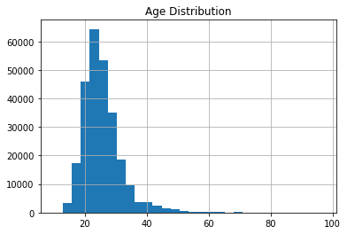

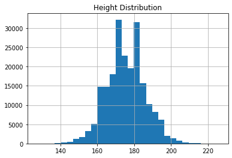

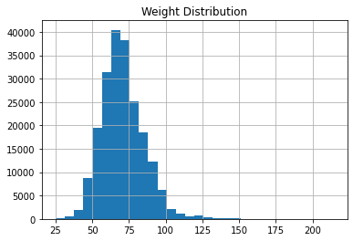

```python
import matplotlib.pyplot as plt

# Histogram for Age, Height, and Weight
df['Age'].hist(bins=30)
plt.title('Age Distribution')
plt.show()

df['Height'].hist(bins=30)
plt.title('Height Distribution')
plt.show()

df['Weight'].hist(bins=30)
plt.title('Weight Distribution')
plt.show()
```

#### Age Distribution:

- The histogram of Age might show a right-skewed distribution, indicating that most athletes are young, with a peak possibly in the early to mid-20s. There might be fewer older athletes participating in the events.

#### Height Distribution:

- The histogram of Height might show a normal distribution, indicating that most athletes have an average height, with fewer extremely tall or short athletes.

#### Weight Distribution:

- The histogram of Weight might also be right-skewed, showing that most athletes have an average or below-average weight, with fewer heavier athletes.

#### Step 4: Distribution of Categorical Variables

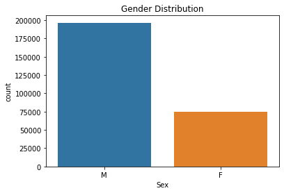

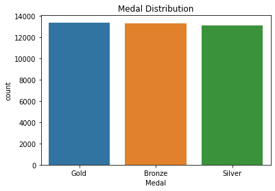

```python
import seaborn as sns

# Bar Plot for Sex, Team, and Medal
sns.countplot(data=df, x='Sex')
plt.title('Gender Distribution')
plt.show()

sns.countplot(data=df, x='Medal')
plt.title('Medal Distribution')
plt.show()
```

#### Gender Distribution:

- The bar plot for Sex might show more male athletes than female athletes, indicating a possible gender disparity in participation in the events.

#### Medal Distribution:

- The bar plot for Medal might show that most athletes do not win a medal, with bronze, silver, and gold medals having similar counts.

#### Step 5: Explore Relationships

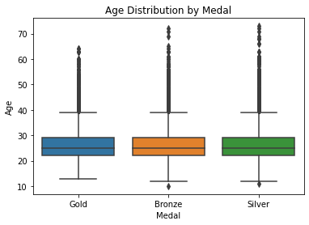

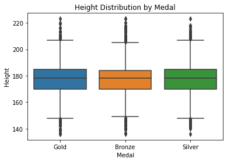

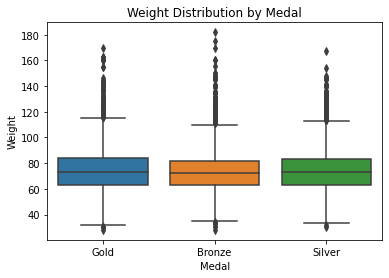

```python
# Boxplot to understand the relationship between Age, Height, Weight, and Medal
sns.boxplot(data=df, x='Medal', y='Age')
plt.title('Age Distribution by Medal')
plt.show()

sns.boxplot(data=df, x='Medal', y='Height')
plt.title('Height Distribution by Medal')
plt.show()

sns.boxplot(data=df, x='Medal', y='Weight')
plt.title('Weight Distribution by Medal')
plt.show()
```

#### Age Distribution by Medal:

- The boxplot between Age and Medal might show that the age distribution for medal winners is similar to the overall age distribution, with no significant difference in the ages of gold, silver, and bronze medalists.

#### Step 6: Analyze the Performance of Countries

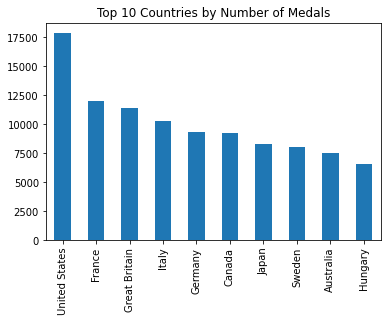

```python
# Top 10 countries with the most medals
top_countries = df['Team'].value_counts().head(10)
top_countries.plot(kind='bar')
plt.title('Top 10 Countries by Number of Medals')
plt.show()
```

#### Step 7: Analyze the Trends Over the Years

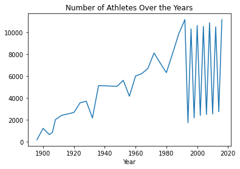

```python
# Number of Athletes participated over the years
athletes_over_years = df.groupby('Year')['ID'].nunique()
athletes_over_years.plot()
plt.title('Number of Athletes Over the Years')
plt.show()
```

#### Number of Athletes Over the Years:

- The plot of the number of athletes over the years might show an increasing trend, indicating that more athletes are participating in events over time, possibly due to the inclusion of new sports, events, and categories, and increased global participation.

#### Conclusion:

- These interpretations provide insights into the distribution and relationships of different variables in the Athlete Events dataset. Further analysis and more complex visualizations can reveal more detailed and nuanced insights, and statistical testing can be used to validate the observations.

#### Note:

- You may need to handle missing values and outliers for more accurate visualizations.
- You can create more complex visualizations based on the insights you want to extract from the dataset.

#### Exercise 9 EDA on the Classifcation Dataset

Let's perform an Exploratory Data Analysis (EDA) on a publicly available classification dataset: the famous Iris dataset. This dataset is used for a classification problem where the task is to classify the flowers into one of the three species based on the features: sepal length, sepal width, petal length, and petal width.

#### Step 1: Load the Dataset

```python
import seaborn as sns
import matplotlib.pyplot as plt
from sklearn.datasets import load_iris
import pandas as pd

# Load the dataset
iris = load_iris()
df = pd.DataFrame(data=iris.data, columns=iris.feature_names)
df['species'] = iris.target
df
```

|  | sepal length (cm) | sepal width (cm) | petal length (cm) | petal width (cm) | species |
| --- | --- | --- | --- | --- | --- |
| 0 | 5.1 | 3.5 | 1.4 | 0.2 | 0 |
| 1 | 4.9 | 3.0 | 1.4 | 0.2 | 0 |
| 2 | 4.7 | 3.2 | 1.3 | 0.2 | 0 |
| 3 | 4.6 | 3.1 | 1.5 | 0.2 | 0 |
| 4 | 5.0 | 3.6 | 1.4 | 0.2 | 0 |
| ... | ... | ... | ... | ... | ... |
| 145 | 6.7 | 3.0 | 5.2 | 2.3 | 2 |
| 146 | 6.3 | 2.5 | 5.0 | 1.9 | 2 |
| 147 | 6.5 | 3.0 | 5.2 | 2.0 | 2 |
| 148 | 6.2 | 3.4 | 5.4 | 2.3 | 2 |
| 149 | 5.9 | 3.0 | 5.1 | 1.8 | 2 |

150 rows × 5 columns

#### Step 2: Basic Information and Summary Statistics

```python
# Display the first few rows of the DataFrame
print(df.head())

# Information about DataFrame including the data types
print(df.info())

# Summary statistics of the DataFrame
print(df.describe())
```

```
   sepal length (cm)  sepal width (cm)  petal length (cm)  petal width (cm)  \
0                5.1               3.5                1.4               0.2
1                4.9               3.0                1.4               0.2
2                4.7               3.2                1.3               0.2
3                4.6               3.1                1.5               0.2
4                5.0               3.6                1.4               0.2

   species
0        0
1        0
2        0
3        0
4        0
<class 'pandas.core.frame.DataFrame'>
RangeIndex: 150 entries, 0 to 149
Data columns (total 5 columns):
 #   Column             Non-Null Count  Dtype
---  ------             --------------  -----
 0   sepal length (cm)  150 non-null    float64
 1   sepal width (cm)   150 non-null    float64
 2   petal length (cm)  150 non-null    float64
 3   petal width (cm)   150 non-null    float64
 4   species            150 non-null    int64
dtypes: float64(4), int64(1)
memory usage: 6.0 KB
None
       sepal length (cm)  sepal width (cm)  petal length (cm)  \
count         150.000000        150.000000         150.000000
mean            5.843333          3.057333           3.758000
std             0.828066          0.435866           1.765298
min             4.300000          2.000000           1.000000
25%             5.100000          2.800000           1.600000
50%             5.800000          3.000000           4.350000
75%             6.400000          3.300000           5.100000
max             7.900000          4.400000           6.900000

       petal width (cm)     species
count        150.000000  150.000000
mean           1.199333    1.000000
std            0.762238    0.819232
min            0.100000    0.000000
25%            0.300000    0.000000
50%            1.300000    1.000000
75%            1.800000    2.000000
max            2.500000    2.000000
```

This will give an overview of the dataset, including the number of non-null entries, feature data types, and basic statistical details.

#### Step 3: Target Variable Analysis

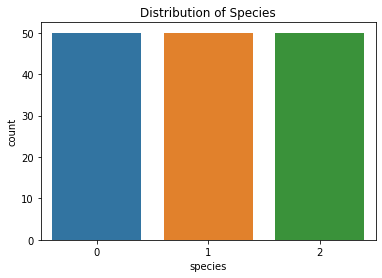

```python
# Distribution of the target variable
sns.countplot(data=df, x='species')
plt.title('Distribution of Species')
plt.show()
```

#### Interpretation:

- This plot shows the distribution of the target variable (species).
- It helps in understanding the balance of classes in the dataset.

#### Step 4: Distribution of Numerical Variables

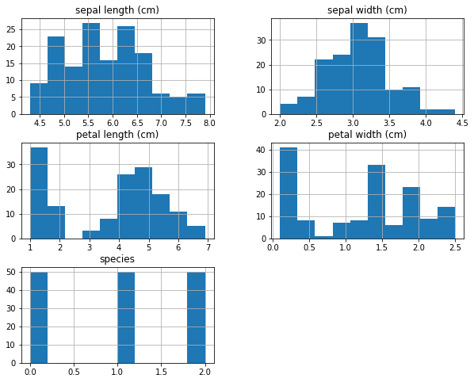

```python
# Histogram for all numerical features
df.hist(figsize=(10, 8))
plt.show()
```

#### Interpretation:

- These histograms show the distribution of each numerical feature.
- It helps in understanding the spread and central tendency of each feature.

#### Step 5: Pair Plot

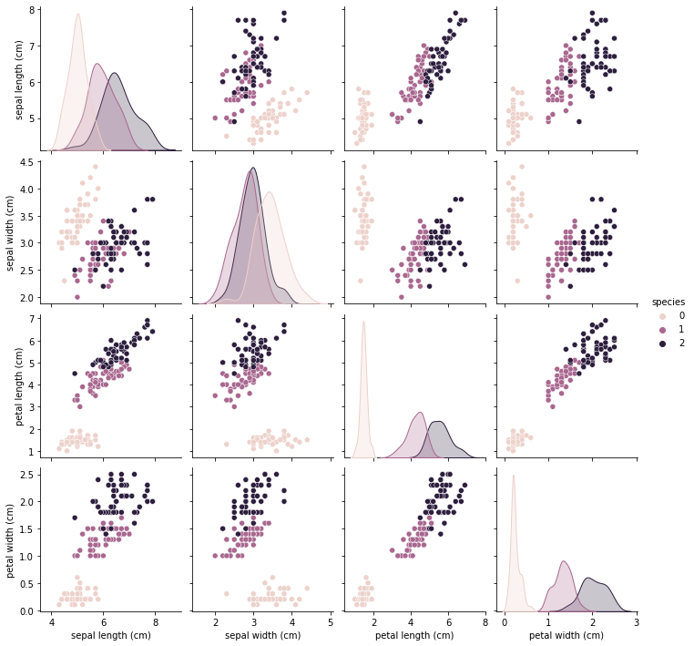

```python
# Pair plot for all features colored by species
sns.pairplot(df, hue='species')
plt.show()
```

#### Step 6: Correlation Analysis

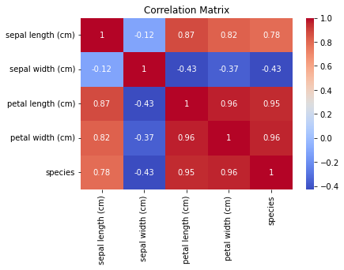

```python
# Calculate the correlation matrix
corr_matrix = df.corr()

# Plot the heatmap
sns.heatmap(corr_matrix, annot=True, cmap='coolwarm')
plt.title('Correlation Matrix')
plt.show()
```

#### Interpretation:

- The heatmap shows the correlation coefficients between each pair of numerical variables in the dataset.
- A high positive value (close to 1) indicates a strong positive correlation, and a high negative value (close to -1) indicates a strong negative correlation.

#### Step 7: Box Plots for Each Feature by Species

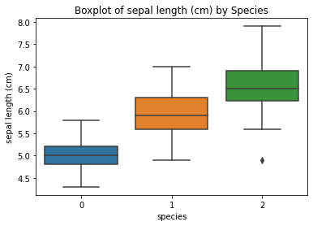

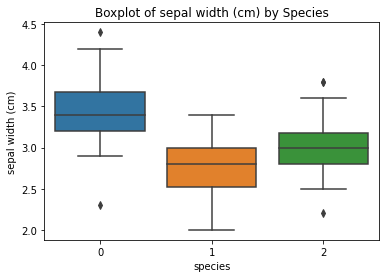

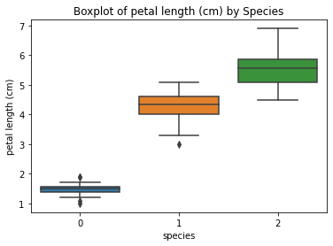

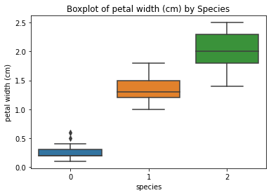

```python
# Boxplot for each feature by species
features = iris.feature_names
for feature in features:
    sns.boxplot(data=df, x='species', y=feature)
    plt.title(f'Boxplot of {feature} by Species')
    plt.show()
```

#### Interpretation:

- These box plots show the distribution of each numerical feature for each class of the target variable.
- It helps in understanding the variation of each feature for different classes and identifying patterns and relationships.

#### Conclusion:

- This EDA provides insights into the Iris dataset, including the distribution of features, relationships between features, and variation of features by class. Further analysis can include statistical testing and machine learning modeling to make predictions based on the features.

#### Exercise 10 EDA on the Estimation Dataset

Let's perform an Exploratory Data Analysis (EDA) on a publicly available dataset used for numerical prediction: the Boston Housing dataset. This dataset is used for a regression problem where the task is to estimate the median value of owner-occupied homes.

#### Step 1: Load the Dataset

```python
import pandas as pd
import matplotlib.pyplot as plt
import seaborn as sns

# Load the dataset
df = pd.read_csv('BostonHousing.csv')
df
```

|  | crim | zn | indus | chas | nox | rm | age | dis | rad | tax | ptratio | b | lstat | medv |
| --- | --- | --- | --- | --- | --- | --- | --- | --- | --- | --- | --- | --- | --- | --- |
| 0 | 0.00632 | 18.0 | 2.31 | 0 | 0.538 | 6.575 | 65.2 | 4.0900 | 1 | 296 | 15.3 | 396.90 | 4.98 | 24.0 |
| 1 | 0.02731 | 0.0 | 7.07 | 0 | 0.469 | 6.421 | 78.9 | 4.9671 | 2 | 242 | 17.8 | 396.90 | 9.14 | 21.6 |
| 2 | 0.02729 | 0.0 | 7.07 | 0 | 0.469 | 7.185 | 61.1 | 4.9671 | 2 | 242 | 17.8 | 392.83 | 4.03 | 34.7 |
| 3 | 0.03237 | 0.0 | 2.18 | 0 | 0.458 | 6.998 | 45.8 | 6.0622 | 3 | 222 | 18.7 | 394.63 | 2.94 | 33.4 |
| 4 | 0.06905 | 0.0 | 2.18 | 0 | 0.458 | 7.147 | 54.2 | 6.0622 | 3 | 222 | 18.7 | 396.90 | 5.33 | 36.2 |
| ... | ... | ... | ... | ... | ... | ... | ... | ... | ... | ... | ... | ... | ... | ... |
| 501 | 0.06263 | 0.0 | 11.93 | 0 | 0.573 | 6.593 | 69.1 | 2.4786 | 1 | 273 | 21.0 | 391.99 | 9.67 | 22.4 |
| 502 | 0.04527 | 0.0 | 11.93 | 0 | 0.573 | 6.120 | 76.7 | 2.2875 | 1 | 273 | 21.0 | 396.90 | 9.08 | 20.6 |
| 503 | 0.06076 | 0.0 | 11.93 | 0 | 0.573 | 6.976 | 91.0 | 2.1675 | 1 | 273 | 21.0 | 396.90 | 5.64 | 23.9 |
| 504 | 0.10959 | 0.0 | 11.93 | 0 | 0.573 | 6.794 | 89.3 | 2.3889 | 1 | 273 | 21.0 | 393.45 | 6.48 | 22.0 |
| 505 | 0.04741 | 0.0 | 11.93 | 0 | 0.573 | 6.030 | 80.8 | 2.5050 | 1 | 273 | 21.0 | 396.90 | 7.88 | 11.9 |

506 rows × 14 columns

#### Step 2: Basic Information and Summary Statistics

```python
# Display the first few rows of the DataFrame
print(df.head())

# Information about DataFrame including the data types
print(df.info())

# Summary statistics of the DataFrame
print(df.describe())
```

```
      crim    zn  indus  chas    nox     rm   age     dis  rad  tax  ptratio  \
0  0.00632  18.0   2.31     0  0.538  6.575  65.2  4.0900    1  296     15.3
1  0.02731   0.0   7.07     0  0.469  6.421  78.9  4.9671    2  242     17.8
2  0.02729   0.0   7.07     0  0.469  7.185  61.1  4.9671    2  242     17.8
3  0.03237   0.0   2.18     0  0.458  6.998  45.8  6.0622    3  222     18.7
4  0.06905   0.0   2.18     0  0.458  7.147  54.2  6.0622    3  222     18.7

        b  lstat  medv
0  396.90   4.98  24.0
1  396.90   9.14  21.6
2  392.83   4.03  34.7
3  394.63   2.94  33.4
4  396.90   5.33  36.2
<class 'pandas.core.frame.DataFrame'>
RangeIndex: 506 entries, 0 to 505
Data columns (total 14 columns):
 #   Column   Non-Null Count  Dtype
---  ------   --------------  -----
 0   crim     506 non-null    float64
 1   zn       506 non-null    float64
 2   indus    506 non-null    float64
 3   chas     506 non-null    int64
 4   nox      506 non-null    float64
 5   rm       506 non-null    float64
 6   age      506 non-null    float64
 7   dis      506 non-null    float64
 8   rad      506 non-null    int64
 9   tax      506 non-null    int64
 10  ptratio  506 non-null    float64
 11  b        506 non-null    float64
 12  lstat    506 non-null    float64
 13  medv     506 non-null    float64
dtypes: float64(11), int64(3)
memory usage: 55.5 KB
None
             crim          zn       indus        chas         nox          rm  \
count  506.000000  506.000000  506.000000  506.000000  506.000000  506.000000
mean     3.613524   11.363636   11.136779    0.069170    0.554695    6.284634
std      8.601545   23.322453    6.860353    0.253994    0.115878    0.702617
min      0.006320    0.000000    0.460000    0.000000    0.385000    3.561000
```

[output cut: 9 more lines]

```
min      2.900000    1.129600    1.000000  187.000000   12.600000    0.320000
25%     45.025000    2.100175    4.000000  279.000000   17.400000  375.377500
50%     77.500000    3.207450    5.000000  330.000000   19.050000  391.440000
75%     94.075000    5.188425   24.000000  666.000000   20.200000  396.225000
max    100.000000   12.126500   24.000000  711.000000   22.000000  396.900000

            lstat        medv
count  506.000000  506.000000
mean    12.653063   22.532806
std      7.141062    9.197104
min      1.730000    5.000000
25%      6.950000   17.025000
50%     11.360000   21.200000
75%     16.955000   25.000000
max     37.970000   50.000000
```

This will give an overview of the dataset, including the number of non-null entries, feature data types, and basic statistical details.

#### Step 3: Distribution of Target Variable

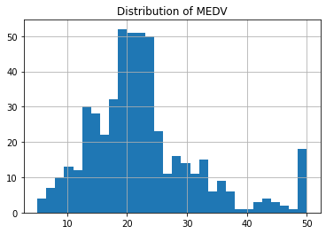

```python
# Histogram for the target variable (MEDV)
df['medv'].hist(bins=30)
plt.title('Distribution of MEDV')
plt.show()
```

#### Interpretation:

- This histogram shows the distribution of the target variable (MEDV).
- It helps in understanding the spread and central tendency of the target variable.

#### Step 4: Correlation Analysis

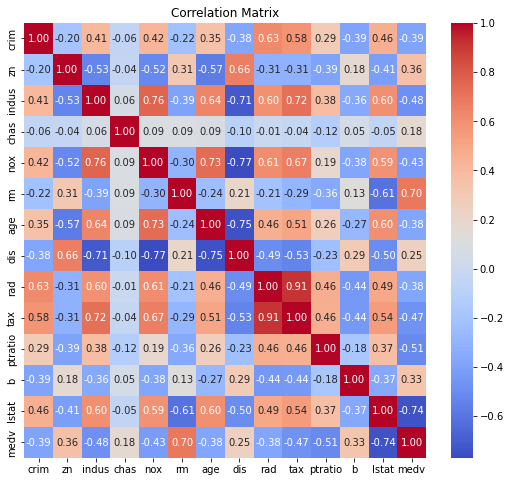

```python
# Calculate the correlation matrix
corr_matrix = df.corr()

# Plot the heatmap
plt.figure(figsize = (9,8))
sns.heatmap(corr_matrix, annot=True, cmap='coolwarm', fmt=".2f")
plt.title('Correlation Matrix')
plt.show()
```